# Midterm

1 November 2020

#### Instructions

- Leave all the calls to `check()` where they are, and use these to verify that you got the right answer.
- Answer the following questions, and show all your R code.
- Upload your submission to Canvas in nicely formatted HTML generated from Rstudio.

## 1

(2 pts)

Use `seq` to create a vector `x` containing the sequence -2.0, -1.9, …, 4.9, 5.0.

```r
x = seq(from = -2.0, to = 5.0, by = .1)
check(x[1] == -2)
```

```
## PASS
```

```r
check(length(x) == 71)
```

```
## PASS
```

## 2

(4 pts)

The function `dunif` in R evaluates the probability density function (PDF) for the uniform distribution on the interval from ‘min’ to ‘max’.

- Call `dunif` on `x` to create and plot three lines with different colors on the same graph.
- Add titles and axis labels as appropriate.

Your plot should include one line for the PDF of a Uniform(0, 1) distribution, one line for the PDF of a Uniform(-1, 2) distribution, and one line for the PDF of a Uniform(0.5, 2.5) distribution. Hint: You can compute the PDF of a Uniform(a, b) distribution with `dunif(..., min = a, max = b)`.

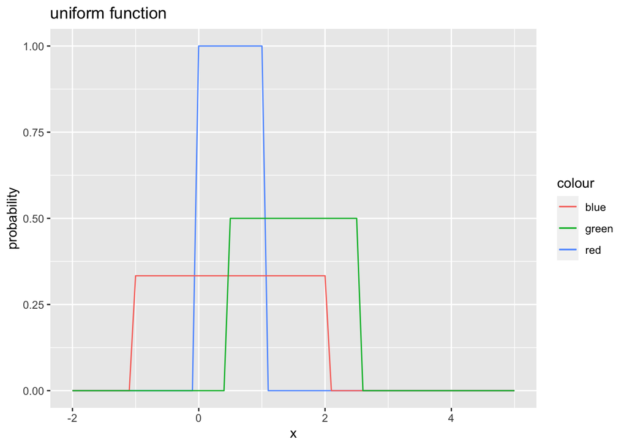

```r
df_uniform = data.frame(x)
df_uniform$unif1 = dunif(x, min =  0, max = 1)
df_uniform$unif2 = dunif(x, min =  -1, max = 2)
df_uniform$unif3 = dunif(x, min =  .5, max = 2.5)
g = ggplot() +
  geom_line(data = df_uniform, mapping = aes(x = x, y = unif1, color = "red")) +
  geom_line(data = df_uniform, mapping = aes(x = x, y = unif2, color = "blue")) +
  geom_line(data = df_uniform, mapping = aes(x = x, y = unif3, color = "green")) +
  labs(title = "uniform function", xlab = "x value", ylab = "probability") +
  ylab("probability")
g
```

## 3

(5 pts)

Define and implement a function `dunif2` that accepts the arguments `x`, `min`, `max`, and behaves exactly like `dunif`. Don’t do `dunif2 = dunif`, that’s cheating :) Don’t worry about the `log` argument to `dunif`.

```r
result = rep(0, length(x))

dunif2 = function(x, min = 0, max = 1) {
  p = 1 / (max - min)
  condition = ( (x >= min) & (x <= max))
  ifelse(condition, p, 0)
}



x3 = seq(from = -10, to = 10)
check(close_enough(
  dunif(x3), dunif2(x3)
))
```

```
## PASS
```

```r
check(close_enough(
  dunif(x3, min = -0.5, max = 2.5),
  dunif2(x3, min = -0.5, max = 2.5)
))
```

```
## PASS
```

## 4

(3 pts)

Define `mtcars2` by selecting the rows of `mtcars` that have `mpg` higher than the median value of `mpg`, and have `cyl` equal to 4.

```r
median_mpg = median(mtcars$mpg)
number_cyl = 4
boolean_mask_4 = ( (mtcars$mpg > median_mpg) & (mtcars$cyl == number_cyl) )
mtcars2 = mtcars[boolean_mask_4,]
check(nrow(mtcars2) == 11)
```

```
## PASS
```

## 5

(2 pts)

In the following broken code, the goal was to produce a scatter plot of the `mtcars` data frame with `disp` on the x axis, and `mpg` on the y axis, and color determined by `gear`. Fix the code so it makes the correct plot.

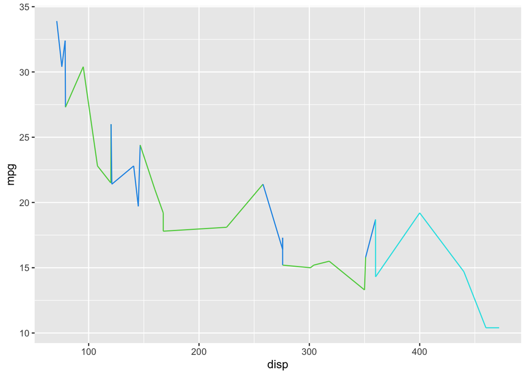

```r
# View(mtcars)
g = ggplot(data = mtcars) +
 geom_line(aes(x = disp, y = mpg), color = mtcars$gear, data = mtcars)

print(g)
```

## 6

(4 pts)

Suppose you want to know the length of several objects in a list, so you write the following code:

```r
l = list(letters, LETTERS, 1:10, rnorm(5))

l_len = c(length(l[[1]]), length(l[[2]]), length(l[[3]]), length(l[[4]]))
```

What is wrong with the above approach to calculating the length of each element?

you are writing the same code repeatedly.

Define `l_len2` by computing the lengths of all elements in `l` in an idiomatic way.

```r
# TODO
l_len2 = sapply(l, FUN = length)
check(close_enough(l_len, l_len2))
```

```
## PASS
```

## Auto Score

Your score below doesn’t include parts of the assignment that aren’t automatically graded, for example, plots, short answers, and data interpretation.

```
## [1] "Auto score:  6 / 6 total points"
```